# BIG MART SALES PREDICTION

Annie N

# Loading necessary libraries

```r
library(data.table)
library(dplyr)
```

```r
library(ggplot2)
library(caret)
library(corrplot)
library(xgboost)
library(cowplot)
library(gridExtra)
library(dummies)
library(stringr)
```

# Reading data

```r
train <- read.csv('train_v9rqX0R.csv') # Loading training data
test <- read.csv('test_AbJTz2l.csv') # Loading testing data
submission <- read.csv('sample_submission_8RXa3c6.csv') # Loading submission data
```

## Exploring training data

```r
str(train)
```

```
## 'data.frame':    8523 obs. of  12 variables:
##  $ Item_Identifier          : chr  "FDA15" "DRC01" "FDN15" "FDX07" ...
##  $ Item_Weight              : num  9.3 5.92 17.5 19.2 8.93 ...
##  $ Item_Fat_Content         : chr  "Low Fat" "Regular" "Low Fat" "Regular" ...
##  $ Item_Visibility          : num  0.016 0.0193 0.0168 0 0 ...
##  $ Item_Type                : chr  "Dairy" "Soft Drinks" "Meat" "Fruits and Vegetables" ...
##  $ Item_MRP                 : num  249.8 48.3 141.6 182.1 53.9 ...
##  $ Outlet_Identifier        : chr  "OUT049" "OUT018" "OUT049" "OUT010" ...
##  $ Outlet_Establishment_Year: int  1999 2009 1999 1998 1987 2009 1987 1985 2002 2007 ...
##  $ Outlet_Size              : chr  "Medium" "Medium" "Medium" "" ...
##  $ Outlet_Location_Type     : chr  "Tier 1" "Tier 3" "Tier 1" "Tier 3" ...
##  $ Outlet_Type              : chr  "Supermarket Type1" "Supermarket Type2" "Supermarket Type1" "Grocery Store" ...
##  $ Item_Outlet_Sales        : num  3735 443 2097 732 995 ...
```

```r
summary(train)
```

```
##  Item_Identifier     Item_Weight     Item_Fat_Content   Item_Visibility
##  Length:8523        Min.   : 4.555   Length:8523        Min.   :0.00000
##  Class :character   1st Qu.: 8.774   Class :character   1st Qu.:0.02699
##  Mode  :character   Median :12.600   Mode  :character   Median :0.05393
##                     Mean   :12.858                      Mean   :0.06613
##                     3rd Qu.:16.850                      3rd Qu.:0.09459
##                     Max.   :21.350                      Max.   :0.32839
##                     NA's   :1463
##   Item_Type            Item_MRP      Outlet_Identifier
##  Length:8523        Min.   : 31.29   Length:8523
##  Class :character   1st Qu.: 93.83   Class :character
##  Mode  :character   Median :143.01   Mode  :character
##                     Mean   :140.99
##                     3rd Qu.:185.64
##                     Max.   :266.89
##
##  Outlet_Establishment_Year Outlet_Size        Outlet_Location_Type
##  Min.   :1985              Length:8523        Length:8523
##  1st Qu.:1987              Class :character   Class :character
##  Median :1999              Mode  :character   Mode  :character
##  Mean   :1998
##  3rd Qu.:2004
##  Max.   :2009
##
##  Outlet_Type        Item_Outlet_Sales
##  Length:8523        Min.   :   33.29
##  Class :character   1st Qu.:  834.25
##  Mode  :character   Median : 1794.33
##                     Mean   : 2181.29
##                     3rd Qu.: 3101.30
##                     Max.   :13086.97
##
```

The training dataset contains 8523 obervations of 12 variables, including 1 dependent/target variable (Item_Outlet_sales) and 11 independent variables.There are missing values in Item_weight.

## Exploring testing data

```r
str(test)
```

```
## 'data.frame':    5681 obs. of  11 variables:
##  $ Item_Identifier          : chr  "FDW58" "FDW14" "NCN55" "FDQ58" ...
##  $ Item_Weight              : num  20.75 8.3 14.6 7.32 NA ...
##  $ Item_Fat_Content         : chr  "Low Fat" "reg" "Low Fat" "Low Fat" ...
##  $ Item_Visibility          : num  0.00756 0.03843 0.09957 0.01539 0.1186 ...
##  $ Item_Type                : chr  "Snack Foods" "Dairy" "Others" "Snack Foods" ...
##  $ Item_MRP                 : num  107.9 87.3 241.8 155 234.2 ...
##  $ Outlet_Identifier        : chr  "OUT049" "OUT017" "OUT010" "OUT017" ...
##  $ Outlet_Establishment_Year: int  1999 2007 1998 2007 1985 1997 2009 1985 2002 2007 ...
##  $ Outlet_Size              : chr  "Medium" "" "" "" ...
##  $ Outlet_Location_Type     : chr  "Tier 1" "Tier 2" "Tier 3" "Tier 2" ...
##  $ Outlet_Type              : chr  "Supermarket Type1" "Supermarket Type1" "Grocery Store" "Supermarket Type1" ...
```

```r
summary(test)
```

```
##  Item_Identifier     Item_Weight     Item_Fat_Content   Item_Visibility
##  Length:5681        Min.   : 4.555   Length:5681        Min.   :0.00000
##  Class :character   1st Qu.: 8.645   Class :character   1st Qu.:0.02705
##  Mode  :character   Median :12.500   Mode  :character   Median :0.05415
##                     Mean   :12.696                      Mean   :0.06568
##                     3rd Qu.:16.700                      3rd Qu.:0.09346
##                     Max.   :21.350                      Max.   :0.32364
##                     NA's   :976
##   Item_Type            Item_MRP      Outlet_Identifier
##  Length:5681        Min.   : 31.99   Length:5681
##  Class :character   1st Qu.: 94.41   Class :character
##  Mode  :character   Median :141.42   Mode  :character
##                     Mean   :141.02
##                     3rd Qu.:186.03
##                     Max.   :266.59
##
##  Outlet_Establishment_Year Outlet_Size        Outlet_Location_Type
##  Min.   :1985              Length:5681        Length:5681
##  1st Qu.:1987              Class :character   Class :character
##  Median :1999              Mode  :character   Mode  :character
##  Mean   :1998
##  3rd Qu.:2004
##  Max.   :2009
##
##  Outlet_Type
##  Length:5681
##  Class :character
##  Mode  :character
##
##
##
##
```

The testing dataset contains 5681 observations of 11 indepdent variables. There is no target variable (Item_Outlet_sales) because we would use this dataset to predict. There are 976 missing values in Item_weight

```r
str(submission)
```

```
## 'data.frame':    5681 obs. of  3 variables:
##  $ Item_Identifier  : chr  "FDW58" "FDW14" "NCN55" "FDQ58" ...
##  $ Outlet_Identifier: chr  "OUT049" "OUT017" "OUT010" "OUT017" ...
##  $ Item_Outlet_Sales: int  1000 1000 1000 1000 1000 1000 1000 1000 1000 1000 ...
```

```r
summary(submission)
```

```
##  Item_Identifier    Outlet_Identifier  Item_Outlet_Sales
##  Length:5681        Length:5681        Min.   :1000
##  Class :character   Class :character   1st Qu.:1000
##  Mode  :character   Mode  :character   Median :1000
##                                        Mean   :1000
##                                        3rd Qu.:1000
##                                        Max.   :1000
```

The Sample Submission dataset contains the format that we have to predict.

# Combinning our train and test dataset

```r
test$Item_Outlet_Sales <- NA
data_combined <- rbind(train, test)
dim(data_combined)
```

```
## [1] 14204    12
```

# Exploring numerical independent variable

```r
train_numeric = dplyr::select_if(train, is.numeric)
names(train_numeric)
```

```
## [1] "Item_Weight"               "Item_Visibility"
## [3] "Item_MRP"                  "Outlet_Establishment_Year"
## [5] "Item_Outlet_Sales"
```

## Visualizing numerical independent variable

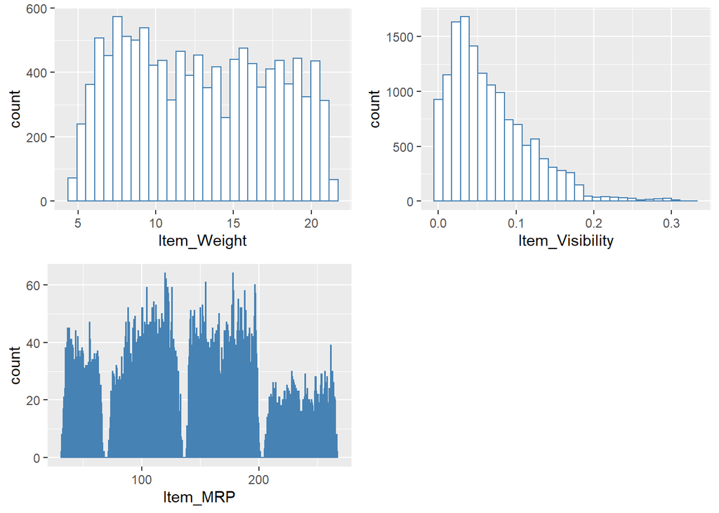

```r
plot_weight <- ggplot(data_combined) + geom_histogram(aes(Item_Weight), color="steelblue", fill="white")
plot_visibility <- ggplot(data_combined) + geom_histogram(aes(Item_Visibility), color="steelblue", fill="white")
plot_mrp <- ggplot(data_combined) + geom_histogram(aes(Item_MRP), color="steelblue", fill="white", binwidth = 0.5)
grid.arrange(plot_weight, plot_visibility, plot_mrp, ncol = 2, nrow = 2)
```

Observations: * Item_weight: no clear distribution * Item_Visibility: right-skewed * Item_MRP: 4 different distribution

# Exploring categorical independent variables

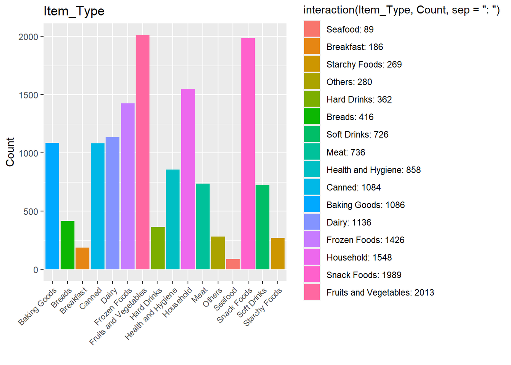

```r
ggplot(data_combined %>% group_by(Item_Type) %>% summarise(Count = n())) +   geom_bar(aes(Item_Type, Count, , fill = interaction(Item_Type, Count, sep = ": ")), stat = "identity") + xlab("") + theme(axis.text.x = element_text(angle = 45, hjust = 1, size = 8)) + ggtitle("Item_Type")
```

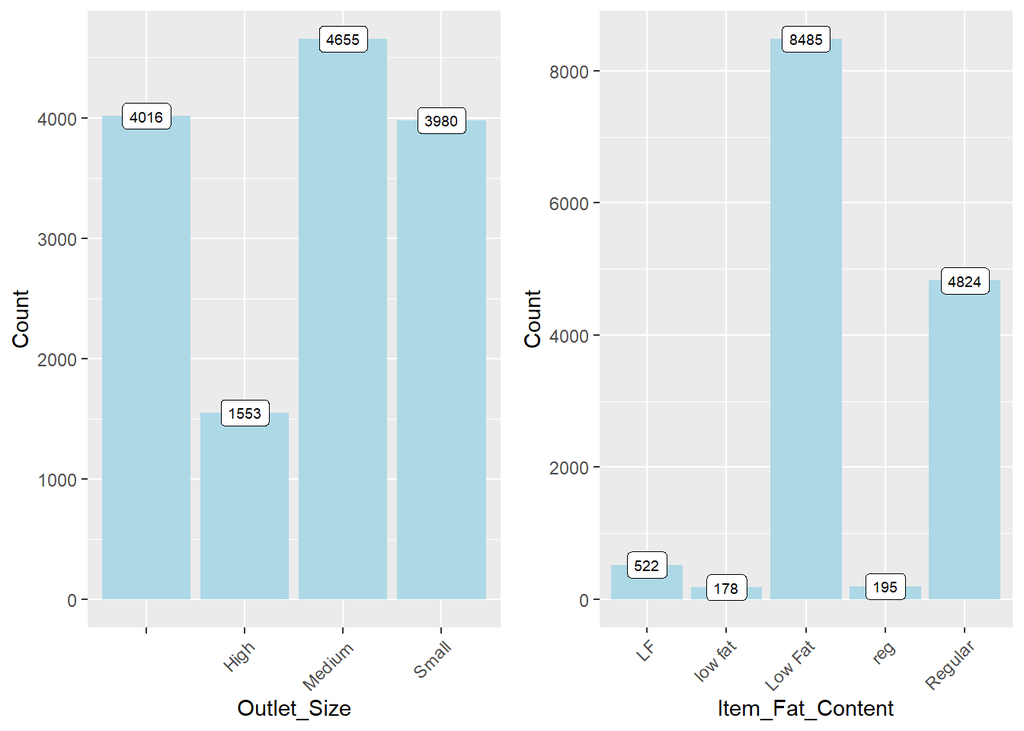

```r
plot_outletSize <- ggplot(data_combined %>% group_by(Outlet_Size) %>% summarise(Count = n())) +   geom_bar(aes(Outlet_Size, Count), stat = "identity", fill = "lightblue") +  geom_label(aes(Outlet_Size, Count, label = Count), vjust = 0.5, size =2.5) +  theme(axis.text.x = element_text(angle = 45, hjust = 1))

plot_fatContent <- ggplot(data_combined %>% group_by(Item_Fat_Content) %>% summarise(Count = n())) +   geom_bar(aes(Item_Fat_Content, Count), stat = "identity", fill = "lightblue") + geom_label(aes(Item_Fat_Content, Count, label = Count), vjust = 0.5, size = 2.5) + theme(axis.text.x = element_text(angle = 45, hjust = 1))

grid.arrange(plot_outletSize, plot_fatContent, ncol = 2)
```

We see that ‘LF’, ‘low fat’ and ‘Low Fat’ are the same category. Besides, ‘reg’ and ‘Regular’ are the same category. We would need to combine these categories into one

# Explore the relationship between numerical independent variables with dependent variable

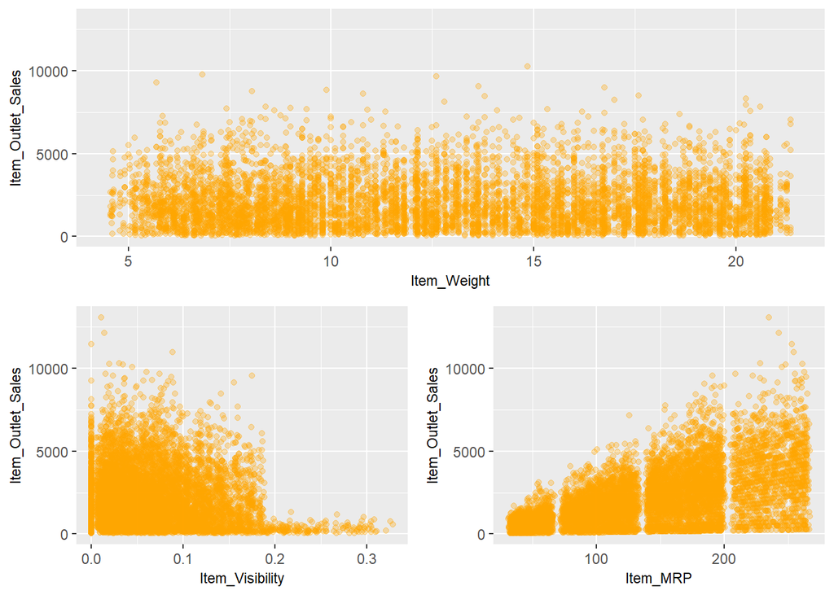

```r
plot1 <- ggplot(train) + geom_point(aes(Item_Weight, Item_Outlet_Sales), colour = "orange", alpha = 0.3) + theme(axis.title = element_text(size = 8.5))

plot2 <- ggplot(train) + geom_point(aes(Item_Visibility, Item_Outlet_Sales), colour = "orange", alpha = 0.3) +theme(axis.title = element_text(size = 8.5))

plot3 <- ggplot(train) + geom_point(aes(Item_MRP, Item_Outlet_Sales), colour = "orange", alpha = 0.3) + theme(axis.title = element_text(size = 8.5))

second_row_2 = plot_grid(plot2, plot3, ncol = 2)
plot_grid(plot1, second_row_2, nrow = 2)
```

Observations:

- Item_Weight vs Item_Outlet_Sales: No obvious pattern
- Item_Visibility vs Item_Outlet_Sales: negative relationship - more visible, lower its sales will be. Besides, there is a number of Item_Visibility that is equal to zero.
- Item_MRP vs Item_Outlet_Sales: 4 different segments of prices

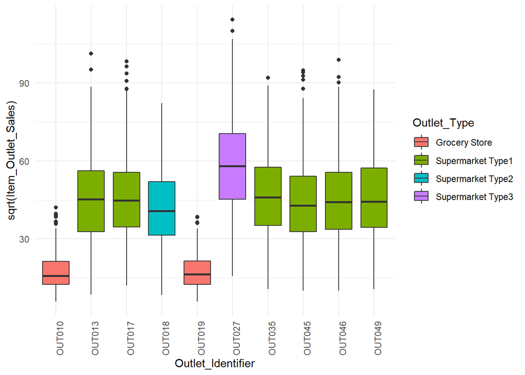

```r
plot4 <- ggplot(train) + geom_boxplot(aes(Outlet_Identifier, sqrt(Item_Outlet_Sales), fill = Outlet_Type)) + theme_minimal() + theme(axis.text.x = element_text(angle = 90))
plot4
```

Customers seem to buy more products at supermarket than grocery store.

# Combining different Item_Fat_Content categories into two categories.

```r
data_combined$Item_Fat_Content <-str_replace(str_replace(str_replace(data_combined$Item_Fat_Content,"LF","Low Fat"),"reg","Regular"),"low fat","Low Fat")

table(data_combined$Item_Fat_Content)
```

```
##
## Low Fat Regular
##    9185    5019
```

# Impute missing value by median in Item_Weight variable

```r
sum(is.na(data_combined$Item_Weight))
```

```
## [1] 2439
```

```r
data_combined$Item_Weight[is.na(data_combined$Item_Weight)] <-
  median(data_combined$Item_Weight, na.rm = TRUE)

sum(is.na(data_combined$Item_Weight))
```

```
## [1] 0
```

# Sub-categorizing the Item_Identifier into Drink(DR), Food(FD) and Non-Consumable (NC)

```r
data_combined <- data_combined %>%
  mutate(Item_Category = substr(Item_Identifier, 1, 2),
         Outlet_Age = 2013 - Outlet_Establishment_Year)

table(data_combined$Item_Category)
```

```
##
##    DR    FD    NC
##  1317 10201  2686
```

```r
data_combined$Item_Fat_Content[data_combined$Item_Category == "NC"] = "Non-Edible"

table(data_combined$Item_Fat_Content)
```

```
##
##    Low Fat Non-Edible    Regular
##       6499       2686       5019
```

# One Hot Encoding for categorical data to prepare machine learning algorithms

```r
data_combined <- dummy.data.frame(data_combined, names = c('Item_Fat_Content', 'Outlet_Size', 'Outlet_Location_Type', 'Outlet_Type', 'Item_Category', 'Outlet_Identifier'), sep ='_')
data_combined <- subset(data_combined, select = -c(Item_Identifier, Item_Type, Outlet_Establishment_Year))

str(data_combined)
```

```
## 'data.frame':    14204 obs. of  32 variables:
##  $ Item_Weight                  : num  9.3 5.92 17.5 19.2 8.93 ...
##  $ Item_Fat_Content_Low Fat     : int  1 0 1 0 0 0 0 1 0 0 ...
##  $ Item_Fat_Content_Non-Edible  : int  0 0 0 0 1 0 0 0 0 0 ...
##  $ Item_Fat_Content_Regular     : int  0 1 0 1 0 1 1 0 1 1 ...
##  $ Item_Visibility              : num  0.016 0.0193 0.0168 0 0 ...
##  $ Item_MRP                     : num  249.8 48.3 141.6 182.1 53.9 ...
##  $ Outlet_Identifier_OUT010     : int  0 0 0 1 0 0 0 0 0 0 ...
##  $ Outlet_Identifier_OUT013     : int  0 0 0 0 1 0 1 0 0 0 ...
##  $ Outlet_Identifier_OUT017     : int  0 0 0 0 0 0 0 0 0 1 ...
##  $ Outlet_Identifier_OUT018     : int  0 1 0 0 0 1 0 0 0 0 ...
##  $ Outlet_Identifier_OUT019     : int  0 0 0 0 0 0 0 0 0 0 ...
##  $ Outlet_Identifier_OUT027     : int  0 0 0 0 0 0 0 1 0 0 ...
##  $ Outlet_Identifier_OUT035     : int  0 0 0 0 0 0 0 0 0 0 ...
##  $ Outlet_Identifier_OUT045     : int  0 0 0 0 0 0 0 0 1 0 ...
```

[output cut: 18 more lines]

# Removing skewness from the variable Item_Visibility

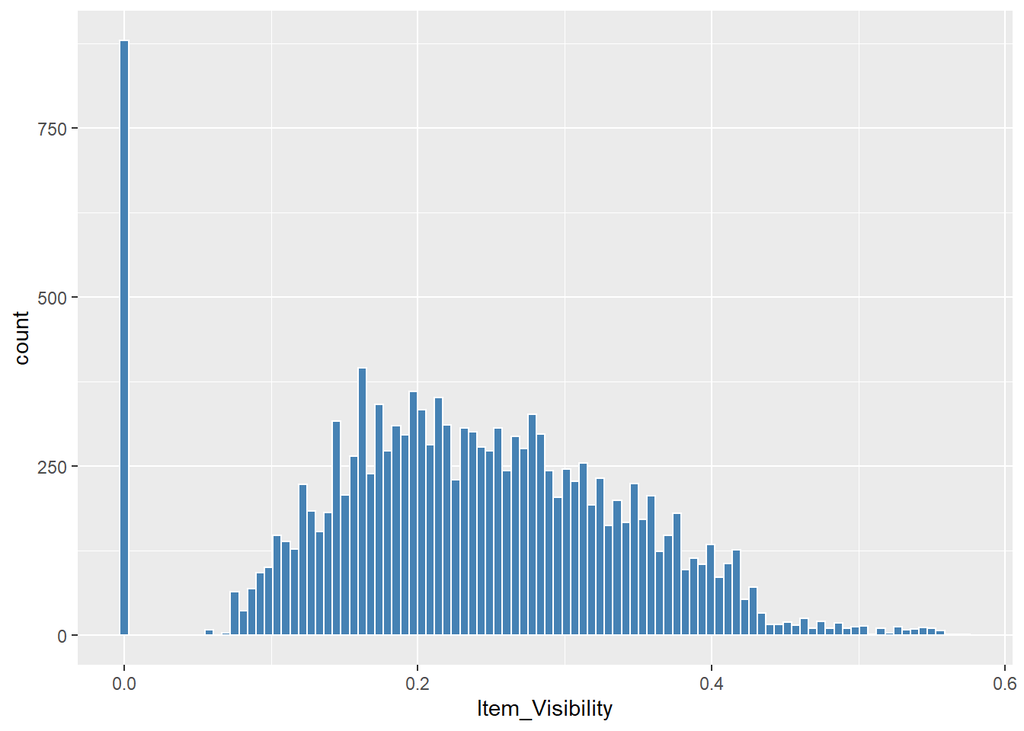

```r
data_combined$Item_Visibility <- sqrt(data_combined$Item_Visibility)
ggplot(data_combined) + geom_histogram(aes(Item_Visibility), bins = 100, color="white", fill="steelblue")
```

# Z-score standardization

```r
data_combined$Item_Weight <- scale(data_combined$Item_Weight, center= TRUE, scale=TRUE)
data_combined$Item_Visibility <- scale(data_combined$Item_Visibility, center= TRUE, scale=TRUE)
data_combined$Item_MRP <- scale(data_combined$Item_MRP, center= TRUE, scale=TRUE)
data_combined$Outlet_Age <- scale(data_combined$Outlet_Age, center= TRUE, scale=TRUE)

str(data_combined)
```

```
## 'data.frame':    14204 obs. of  32 variables:
##  $ Item_Weight                  : num [1:14204, 1] -0.817 -1.615 1.119 1.521 -0.904 ...
##   ..- attr(*, "scaled:center")= num 12.8
##   ..- attr(*, "scaled:scale")= num 4.23
##  $ Item_Fat_Content_Low Fat     : int  1 0 1 0 0 0 0 1 0 0 ...
##  $ Item_Fat_Content_Non-Edible  : int  0 0 0 0 1 0 0 0 0 0 ...
##  $ Item_Fat_Content_Regular     : int  0 1 0 1 0 1 1 0 1 1 ...
##  $ Item_Visibility              : num [1:14204, 1] -0.998 -0.884 -0.972 -2.182 -2.182 ...
##   ..- attr(*, "scaled:center")= num 0.233
##   ..- attr(*, "scaled:scale")= num 0.107
##  $ Item_MRP                     : num [1:14204, 1] 1.75245 -1.49364 0.00987 0.66181 -1.40357 ...
##   ..- attr(*, "scaled:center")= num 141
##   ..- attr(*, "scaled:scale")= num 62.1
##  $ Outlet_Identifier_OUT010     : int  0 0 0 1 0 0 0 0 0 0 ...
##  $ Outlet_Identifier_OUT013     : int  0 0 0 0 1 0 1 0 0 0 ...
```

[output cut: 26 more lines]

# spliting the data_combined into train and test data.

```r
train <- data_combined[1:nrow(train), ]
test <- data_combined[(nrow(train) + 1):nrow(data_combined), ]
test <- subset(test, select = -c(Item_Outlet_Sales))

dim(train)
```

```
## [1] 8523   32
```

```r
dim(test)
```

```
## [1] 5681   31
```

# Corplot to explore the correlation among the variables

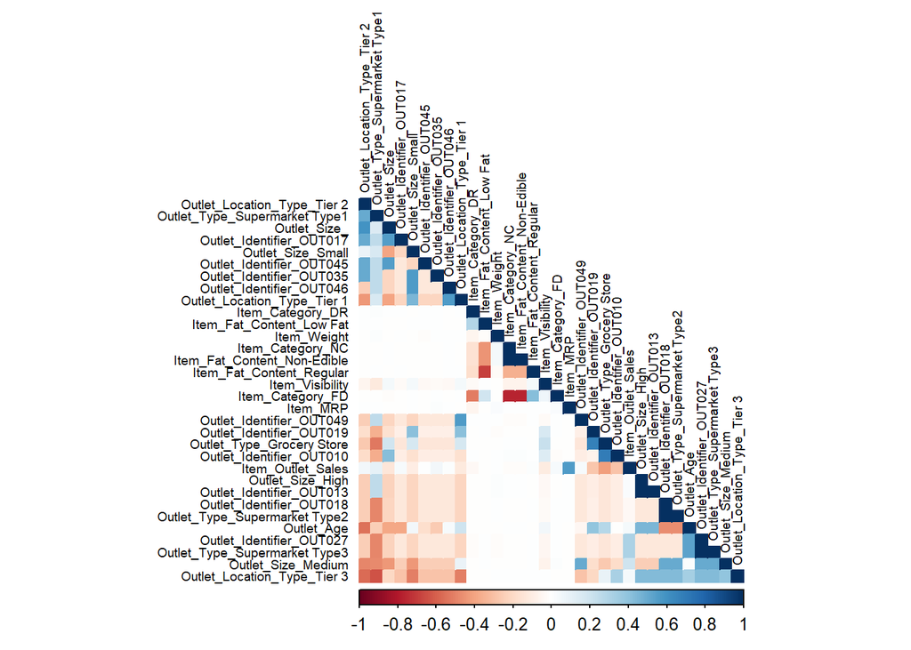

```r
corMatrix <- cor(train[, -35])
corrplot(corMatrix, order = "FPC", method = "color", type = "lower",
         tl.cex = 0.6, tl.col = 'black')
```

# Linear Regression Model

```r
linear_reg_mod = lm(Item_Outlet_Sales ~ ., data = train)
summary(linear_reg_mod)
```

```
##
## Call:
## lm(formula = Item_Outlet_Sales ~ ., data = train)
##
## Residuals:
##     Min      1Q  Median      3Q     Max
## -4306.3  -677.2   -87.9   569.6  7928.5
##
## Coefficients: (16 not defined because of singularities)
##                                  Estimate Std. Error t value Pr(>|t|)
## (Intercept)                      2391.748     40.492  59.067  < 2e-16 ***
## Item_Weight                        -2.427     12.281  -0.198  0.84333
## `Item_Fat_Content_Low Fat`        -41.787     28.281  -1.478  0.13956
## `Item_Fat_Content_Non-Edible`     -70.541     35.065  -2.012  0.04428 *
## Item_Fat_Content_Regular               NA         NA      NA       NA
## Item_Visibility                   -18.155     12.549  -1.447  0.14802
## Item_MRP                          965.963     12.208  79.125  < 2e-16 ***
## Outlet_Identifier_OUT010        -2004.031     61.050 -32.826  < 2e-16 ***
## Outlet_Identifier_OUT013          -66.515     52.304  -1.272  0.20351
## Outlet_Identifier_OUT017            6.274     52.386   0.120  0.90467
## Outlet_Identifier_OUT018         -374.296     52.359  -7.149 9.49e-13 ***
## Outlet_Identifier_OUT019        -1986.804     62.133 -31.977  < 2e-16 ***
## Outlet_Identifier_OUT027         1352.681     52.274  25.877  < 2e-16 ***
## Outlet_Identifier_OUT035           47.115     52.333   0.900  0.36798
## Outlet_Identifier_OUT045         -165.607     52.350  -3.163  0.00156 **
## Outlet_Identifier_OUT046          -97.663     52.333  -1.866  0.06205 .
## Outlet_Identifier_OUT049               NA         NA      NA       NA
## Outlet_Size_                           NA         NA      NA       NA
## Outlet_Size_High                       NA         NA      NA       NA
## Outlet_Size_Medium                     NA         NA      NA       NA
## Outlet_Size_Small                      NA         NA      NA       NA
## `Outlet_Location_Type_Tier 1`          NA         NA      NA       NA
## `Outlet_Location_Type_Tier 2`          NA         NA      NA       NA
## `Outlet_Location_Type_Tier 3`          NA         NA      NA       NA
## `Outlet_Type_Grocery Store`            NA         NA      NA       NA
## `Outlet_Type_Supermarket Type1`        NA         NA      NA       NA
## `Outlet_Type_Supermarket Type2`        NA         NA      NA       NA
## `Outlet_Type_Supermarket Type3`        NA         NA      NA       NA
## Item_Category_DR                  -17.627     43.980  -0.401  0.68858
## Item_Category_FD                       NA         NA      NA       NA
## Item_Category_NC                       NA         NA      NA       NA
## Outlet_Age                             NA         NA      NA       NA
## ---
## Signif. codes:  0 '***' 0.001 '**' 0.01 '*' 0.05 '.' 0.1 ' ' 1
##
## Residual standard error: 1128 on 8507 degrees of freedom
## Multiple R-squared:  0.5635, Adjusted R-squared:  0.5628
## F-statistic: 732.3 on 15 and 8507 DF,  p-value: < 2.2e-16
```

The model seems to be widespread with a lot of insignificant variables. We would remove all insignificant variables and rerun the model again.

```r
linear_reg_mod = lm(Item_Outlet_Sales ~ Item_MRP + Outlet_Identifier_OUT010 + Outlet_Identifier_OUT018 + Outlet_Identifier_OUT019 + Outlet_Identifier_OUT027 + Outlet_Identifier_OUT045, data = train)
summary(linear_reg_mod)
```

```
##
## Call:
## lm(formula = Item_Outlet_Sales ~ Item_MRP + Outlet_Identifier_OUT010 +
##     Outlet_Identifier_OUT018 + Outlet_Identifier_OUT019 + Outlet_Identifier_OUT027 +
##     Outlet_Identifier_OUT045, data = train)
##
## Residuals:
##     Min      1Q  Median      3Q     Max
## -4298.4  -678.1   -82.4   568.9  7911.6
##
## Coefficients:
##                          Estimate Std. Error t value Pr(>|t|)
## (Intercept)               2336.85      16.56 141.127  < 2e-16 ***
## Item_MRP                   966.12      12.19  79.240  < 2e-16 ***
## Outlet_Identifier_OUT010 -1993.96      50.70 -39.329  < 2e-16 ***
## Outlet_Identifier_OUT018  -351.84      40.59  -8.668  < 2e-16 ***
## Outlet_Identifier_OUT019 -1977.57      51.84 -38.144  < 2e-16 ***
## Outlet_Identifier_OUT027  1375.91      40.46  34.004  < 2e-16 ***
## Outlet_Identifier_OUT045  -143.62      40.57  -3.540 0.000402 ***
## ---
## Signif. codes:  0 '***' 0.001 '**' 0.01 '*' 0.05 '.' 0.1 ' ' 1
##
## Residual standard error: 1129 on 8516 degrees of freedom
## Multiple R-squared:  0.5627, Adjusted R-squared:  0.5624
## F-statistic:  1826 on 6 and 8516 DF,  p-value: < 2.2e-16
```

# Prediction on testing data

```r
prediction = predict(linear_reg_mod, test)
```